# Risk Factor Analysis

## Outcome Variable

**Outcome Variable:** pers_wast

## Predictor Variables

**Intervention Variable:** impfloor

**Adjustment Set:**

- arm
- sex
- W_mage
- meducyrs
- feducyrs
- hhwealth_quart
- hfoodsec
- W_mhtcm
- W_mwtkg
- W_mbmi
- W_nrooms
- W_nchldlt5
- W_parity
- impsan
- safeh20
- delta_W_mage
- delta_meducyrs
- delta_feducyrs
- delta_hhwealth_quart
- delta_hfoodsec
- delta_W_mhtcm
- delta_W_mwtkg
- delta_W_mbmi
- delta_W_nrooms
- delta_W_nchldlt5
- delta_W_parity
- delta_impsan
- delta_safeh20

## Stratifying Variables

The analysis was stratified on these variable(s):

- agecat
- studyid
- country

## Data Summary

| agecat | studyid | country | impfloor | pers_wast | n_cell | n |
| --- | --- | --- | --- | --- | --- | --- |
| 0-24 months | CMC-V-BCS-2002 | INDIA | 1 | 0 | 248 | 261 |
| 0-24 months | CMC-V-BCS-2002 | INDIA | 1 | 1 | 13 | 261 |
| 0-24 months | CMC-V-BCS-2002 | INDIA | 0 | 0 | 0 | 261 |
| 0-24 months | CMC-V-BCS-2002 | INDIA | 0 | 1 | 0 | 261 |
| 0-24 months | CONTENT | PERU | 1 | 0 | 201 | 215 |
| 0-24 months | CONTENT | PERU | 1 | 1 | 0 | 215 |
| 0-24 months | CONTENT | PERU | 0 | 0 | 14 | 215 |
| 0-24 months | CONTENT | PERU | 0 | 1 | 0 | 215 |
| 0-24 months | GMS-Nepal | NEPAL | 1 | 0 | 72 | 469 |
| 0-24 months | GMS-Nepal | NEPAL | 1 | 1 | 12 | 469 |
| 0-24 months | GMS-Nepal | NEPAL | 0 | 0 | 331 | 469 |
| 0-24 months | GMS-Nepal | NEPAL | 0 | 1 | 54 | 469 |
| 0-24 months | IRC | INDIA | 1 | 0 | 271 | 306 |
| 0-24 months | IRC | INDIA | 1 | 1 | 35 | 306 |
| 0-24 months | IRC | INDIA | 0 | 0 | 0 | 306 |
| 0-24 months | IRC | INDIA | 0 | 1 | 0 | 306 |
| 0-24 months | JiVitA-3 | BANGLADESH | 1 | 0 | 1313 | 15768 |
| 0-24 months | JiVitA-3 | BANGLADESH | 1 | 1 | 64 | 15768 |
| 0-24 months | JiVitA-3 | BANGLADESH | 0 | 0 | 13563 | 15768 |
| 0-24 months | JiVitA-3 | BANGLADESH | 0 | 1 | 828 | 15768 |
| 0-24 months | JiVitA-4 | BANGLADESH | 1 | 0 | 603 | 5278 |
| 0-24 months | JiVitA-4 | BANGLADESH | 1 | 1 | 22 | 5278 |
| 0-24 months | JiVitA-4 | BANGLADESH | 0 | 0 | 4249 | 5278 |
| 0-24 months | JiVitA-4 | BANGLADESH | 0 | 1 | 404 | 5278 |
| 0-24 months | MAL-ED | BANGLADESH | 1 | 0 | 212 | 242 |
| 0-24 months | MAL-ED | BANGLADESH | 1 | 1 | 11 | 242 |
| 0-24 months | MAL-ED | BANGLADESH | 0 | 0 | 17 | 242 |
| 0-24 months | MAL-ED | BANGLADESH | 0 | 1 | 2 | 242 |
| 0-24 months | MAL-ED | BRAZIL | 1 | 0 | 206 | 210 |
| 0-24 months | MAL-ED | BRAZIL | 1 | 1 | 2 | 210 |

[output cut: 158 more lines]

The following strata were considered:

- agecat: 0-24 months, studyid: CMC-V-BCS-2002, country: INDIA
- agecat: 0-24 months, studyid: CONTENT, country: PERU
- agecat: 0-24 months, studyid: GMS-Nepal, country: NEPAL
- agecat: 0-24 months, studyid: IRC, country: INDIA
- agecat: 0-24 months, studyid: JiVitA-3, country: BANGLADESH
- agecat: 0-24 months, studyid: JiVitA-4, country: BANGLADESH
- agecat: 0-24 months, studyid: MAL-ED, country: BANGLADESH
- agecat: 0-24 months, studyid: MAL-ED, country: BRAZIL
- agecat: 0-24 months, studyid: MAL-ED, country: INDIA
- agecat: 0-24 months, studyid: MAL-ED, country: NEPAL
- agecat: 0-24 months, studyid: MAL-ED, country: PERU
- agecat: 0-24 months, studyid: MAL-ED, country: SOUTH AFRICA
- agecat: 0-24 months, studyid: MAL-ED, country: TANZANIA, UNITED REPUBLIC OF
- agecat: 0-24 months, studyid: NIH-Birth, country: BANGLADESH
- agecat: 0-24 months, studyid: NIH-Crypto, country: BANGLADESH
- agecat: 0-24 months, studyid: PROVIDE, country: BANGLADESH
- agecat: 0-6 months, studyid: CMC-V-BCS-2002, country: INDIA
- agecat: 0-6 months, studyid: CONTENT, country: PERU
- agecat: 0-6 months, studyid: GMS-Nepal, country: NEPAL
- agecat: 0-6 months, studyid: IRC, country: INDIA
- agecat: 0-6 months, studyid: JiVitA-3, country: BANGLADESH
- agecat: 0-6 months, studyid: MAL-ED, country: BANGLADESH
- agecat: 0-6 months, studyid: MAL-ED, country: BRAZIL
- agecat: 0-6 months, studyid: MAL-ED, country: INDIA
- agecat: 0-6 months, studyid: MAL-ED, country: NEPAL
- agecat: 0-6 months, studyid: MAL-ED, country: PERU
- agecat: 0-6 months, studyid: MAL-ED, country: SOUTH AFRICA
- agecat: 0-6 months, studyid: MAL-ED, country: TANZANIA, UNITED REPUBLIC OF
- agecat: 0-6 months, studyid: NIH-Birth, country: BANGLADESH
- agecat: 0-6 months, studyid: NIH-Crypto, country: BANGLADESH
- agecat: 0-6 months, studyid: PROVIDE, country: BANGLADESH
- agecat: 6-24 months, studyid: CMC-V-BCS-2002, country: INDIA
- agecat: 6-24 months, studyid: CONTENT, country: PERU
- agecat: 6-24 months, studyid: GMS-Nepal, country: NEPAL
- agecat: 6-24 months, studyid: IRC, country: INDIA
- agecat: 6-24 months, studyid: JiVitA-3, country: BANGLADESH
- agecat: 6-24 months, studyid: JiVitA-4, country: BANGLADESH
- agecat: 6-24 months, studyid: MAL-ED, country: BANGLADESH
- agecat: 6-24 months, studyid: MAL-ED, country: BRAZIL
- agecat: 6-24 months, studyid: MAL-ED, country: INDIA
- agecat: 6-24 months, studyid: MAL-ED, country: NEPAL
- agecat: 6-24 months, studyid: MAL-ED, country: PERU
- agecat: 6-24 months, studyid: MAL-ED, country: SOUTH AFRICA
- agecat: 6-24 months, studyid: MAL-ED, country: TANZANIA, UNITED REPUBLIC OF
- agecat: 6-24 months, studyid: NIH-Birth, country: BANGLADESH
- agecat: 6-24 months, studyid: NIH-Crypto, country: BANGLADESH
- agecat: 6-24 months, studyid: PROVIDE, country: BANGLADESH

### Dropped Strata

Some strata were dropped due to rare outcomes:

- agecat: 0-24 months, studyid: CMC-V-BCS-2002, country: INDIA
- agecat: 0-24 months, studyid: CONTENT, country: PERU
- agecat: 0-24 months, studyid: IRC, country: INDIA
- agecat: 0-24 months, studyid: MAL-ED, country: BANGLADESH
- agecat: 0-24 months, studyid: MAL-ED, country: BRAZIL
- agecat: 0-24 months, studyid: MAL-ED, country: INDIA
- agecat: 0-24 months, studyid: MAL-ED, country: NEPAL
- agecat: 0-24 months, studyid: MAL-ED, country: PERU
- agecat: 0-24 months, studyid: MAL-ED, country: SOUTH AFRICA
- agecat: 0-24 months, studyid: MAL-ED, country: TANZANIA, UNITED REPUBLIC OF
- agecat: 0-24 months, studyid: PROVIDE, country: BANGLADESH
- agecat: 0-6 months, studyid: CMC-V-BCS-2002, country: INDIA
- agecat: 0-6 months, studyid: CONTENT, country: PERU
- agecat: 0-6 months, studyid: IRC, country: INDIA
- agecat: 0-6 months, studyid: JiVitA-3, country: BANGLADESH
- agecat: 0-6 months, studyid: MAL-ED, country: BANGLADESH
- agecat: 0-6 months, studyid: MAL-ED, country: BRAZIL
- agecat: 0-6 months, studyid: MAL-ED, country: INDIA
- agecat: 0-6 months, studyid: MAL-ED, country: NEPAL
- agecat: 0-6 months, studyid: MAL-ED, country: PERU
- agecat: 0-6 months, studyid: MAL-ED, country: SOUTH AFRICA
- agecat: 0-6 months, studyid: MAL-ED, country: TANZANIA, UNITED REPUBLIC OF
- agecat: 0-6 months, studyid: NIH-Birth, country: BANGLADESH
- agecat: 0-6 months, studyid: NIH-Crypto, country: BANGLADESH
- agecat: 0-6 months, studyid: PROVIDE, country: BANGLADESH
- agecat: 6-24 months, studyid: CMC-V-BCS-2002, country: INDIA
- agecat: 6-24 months, studyid: CONTENT, country: PERU
- agecat: 6-24 months, studyid: IRC, country: INDIA
- agecat: 6-24 months, studyid: MAL-ED, country: BANGLADESH
- agecat: 6-24 months, studyid: MAL-ED, country: BRAZIL
- agecat: 6-24 months, studyid: MAL-ED, country: INDIA
- agecat: 6-24 months, studyid: MAL-ED, country: NEPAL
- agecat: 6-24 months, studyid: MAL-ED, country: PERU
- agecat: 6-24 months, studyid: MAL-ED, country: SOUTH AFRICA
- agecat: 6-24 months, studyid: MAL-ED, country: TANZANIA, UNITED REPUBLIC OF
- agecat: 6-24 months, studyid: PROVIDE, country: BANGLADESH

## Methods Detail

We’re interested in the causal parameters $E[Y_a]$ for all values of $a \in \mathcal{A}$. These parameters represent the mean outcome if, possibly contrary to fact, we intervened to set all units to have $A=a$. Under the randomization and positivity assumptions, these are identified by the statistical parameters $\psi_a=E_W[E_{Y|A,W}(Y|A=a,W)]$. In addition, we’re interested in the mean of $Y$, $E[Y]$ under no intervention (the observed mean). We will estimate these parameters by using SuperLearner to fit the relevant likelihood factors – $E_{Y|A,W}(Y|A=a,W)$ and $p(A=a|W)$, and then updating our likelihood fit using a joint TMLE.

For unadjusted analyses ($W=\{\}$), initial likelihoods were estimated using Lrnr_glm to estimate the simple $E(Y|A)$ and Lrnr_mean to estimate $p(A)$. For adjusted analyses, a small library containing Lrnr_glmnet, Lrnr_xgboost, and Lrnr_mean was used.

Having estimated these parameters, we will then use the delta method to estimate relative risks and attributable risks relative to a prespecified baseline level of $A$.

# Results Detail

## Results Plots

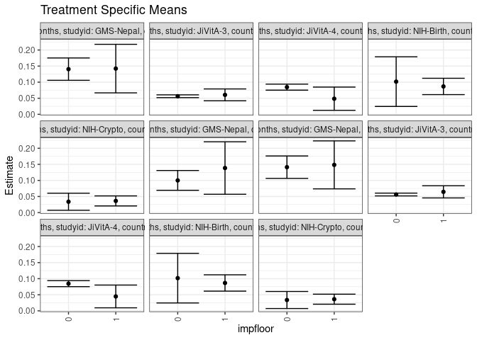

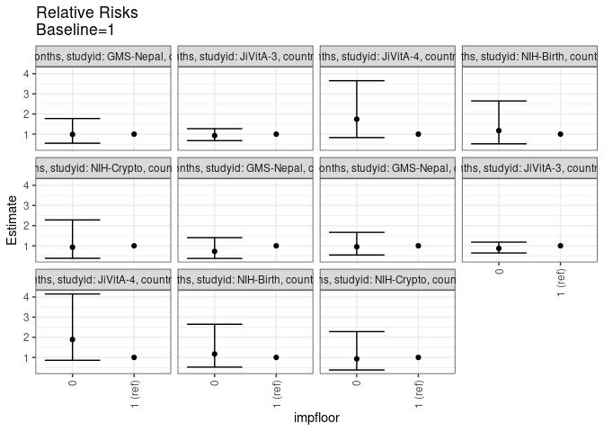

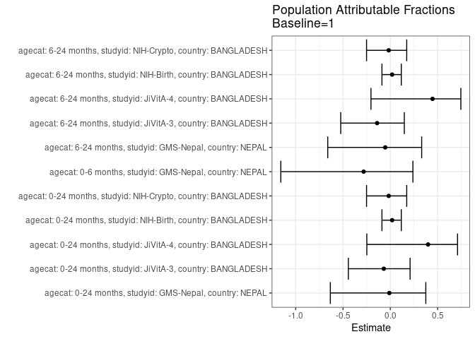

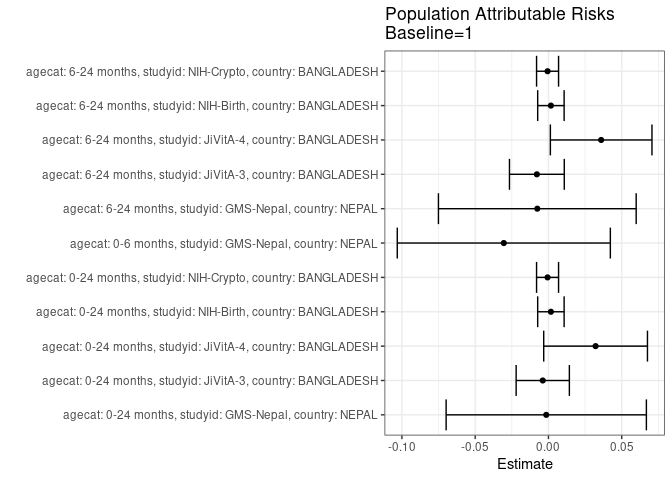

## Results Table

### Parameter: TSM

| agecat | studyid | country | intervention_level | baseline_level | estimate | ci_lower | ci_upper |
| --- | --- | --- | --- | --- | --- | --- | --- |
| 0-24 months | GMS-Nepal | NEPAL | 1 | NA | 0.1422327 | 0.0667657 | 0.2176997 |
| 0-24 months | GMS-Nepal | NEPAL | 0 | NA | 0.1405215 | 0.1057399 | 0.1753030 |
| 0-24 months | JiVitA-3 | BANGLADESH | 1 | NA | 0.0604667 | 0.0420056 | 0.0789279 |
| 0-24 months | JiVitA-3 | BANGLADESH | 0 | NA | 0.0562013 | 0.0518903 | 0.0605122 |
| 0-24 months | JiVitA-4 | BANGLADESH | 1 | NA | 0.0485605 | 0.0124124 | 0.0847086 |
| 0-24 months | JiVitA-4 | BANGLADESH | 0 | NA | 0.0845234 | 0.0751424 | 0.0939043 |
| 0-24 months | NIH-Birth | BANGLADESH | 1 | NA | 0.0866808 | 0.0613003 | 0.1120612 |
| 0-24 months | NIH-Birth | BANGLADESH | 0 | NA | 0.1016949 | 0.0244994 | 0.1788905 |
| 0-24 months | NIH-Crypto | BANGLADESH | 1 | NA | 0.0362319 | 0.0206325 | 0.0518313 |
| 0-24 months | NIH-Crypto | BANGLADESH | 0 | NA | 0.0337079 | 0.0071767 | 0.0602390 |
| 0-6 months | GMS-Nepal | NEPAL | 1 | NA | 0.1385815 | 0.0570361 | 0.2201268 |
| 0-6 months | GMS-Nepal | NEPAL | 0 | NA | 0.1000630 | 0.0692870 | 0.1308390 |
| 6-24 months | GMS-Nepal | NEPAL | 1 | NA | 0.1483392 | 0.0737624 | 0.2229161 |
| 6-24 months | GMS-Nepal | NEPAL | 0 | NA | 0.1412049 | 0.1063888 | 0.1760209 |
| 6-24 months | JiVitA-3 | BANGLADESH | 1 | NA | 0.0644777 | 0.0455090 | 0.0834464 |
| 6-24 months | JiVitA-3 | BANGLADESH | 0 | NA | 0.0562016 | 0.0518889 | 0.0605143 |
| 6-24 months | JiVitA-4 | BANGLADESH | 1 | NA | 0.0447530 | 0.0093718 | 0.0801341 |
| 6-24 months | JiVitA-4 | BANGLADESH | 0 | NA | 0.0845591 | 0.0751665 | 0.0939516 |
| 6-24 months | NIH-Birth | BANGLADESH | 1 | NA | 0.0866808 | 0.0613003 | 0.1120612 |
| 6-24 months | NIH-Birth | BANGLADESH | 0 | NA | 0.1016949 | 0.0244994 | 0.1788905 |
| 6-24 months | NIH-Crypto | BANGLADESH | 1 | NA | 0.0362319 | 0.0206325 | 0.0518313 |
| 6-24 months | NIH-Crypto | BANGLADESH | 0 | NA | 0.0337079 | 0.0071767 | 0.0602390 |

### Parameter: E(Y)

| agecat | studyid | country | intervention_level | baseline_level | estimate | ci_lower | ci_upper |
| --- | --- | --- | --- | --- | --- | --- | --- |
| 0-24 months | GMS-Nepal | NEPAL | NA | NA | 0.1407249 | 0.1092201 | 0.1722298 |
| 0-24 months | JiVitA-3 | BANGLADESH | NA | NA | 0.0565703 | 0.0524546 | 0.0606859 |
| 0-24 months | JiVitA-4 | BANGLADESH | NA | NA | 0.0807124 | 0.0720896 | 0.0893352 |
| 0-24 months | NIH-Birth | BANGLADESH | NA | NA | 0.0883459 | 0.0642074 | 0.1124843 |
| 0-24 months | NIH-Crypto | BANGLADESH | NA | NA | 0.0356164 | 0.0221630 | 0.0490699 |
| 0-6 months | GMS-Nepal | NEPAL | NA | NA | 0.1081081 | 0.0791926 | 0.1370237 |
| 6-24 months | GMS-Nepal | NEPAL | NA | NA | 0.1407249 | 0.1092201 | 0.1722298 |
| 6-24 months | JiVitA-3 | BANGLADESH | NA | NA | 0.0565703 | 0.0524546 | 0.0606859 |
| 6-24 months | JiVitA-4 | BANGLADESH | NA | NA | 0.0807124 | 0.0720896 | 0.0893352 |
| 6-24 months | NIH-Birth | BANGLADESH | NA | NA | 0.0883459 | 0.0642074 | 0.1124843 |
| 6-24 months | NIH-Crypto | BANGLADESH | NA | NA | 0.0356164 | 0.0221630 | 0.0490699 |

### Parameter: RR

| agecat | studyid | country | intervention_level | baseline_level | estimate | ci_lower | ci_upper |
| --- | --- | --- | --- | --- | --- | --- | --- |
| 0-24 months | GMS-Nepal | NEPAL | 1 | 1 | 1.0000000 | 1.0000000 | 1.000000 |
| 0-24 months | GMS-Nepal | NEPAL | 0 | 1 | 0.9879689 | 0.5497915 | 1.775368 |
| 0-24 months | JiVitA-3 | BANGLADESH | 1 | 1 | 1.0000000 | 1.0000000 | 1.000000 |
| 0-24 months | JiVitA-3 | BANGLADESH | 0 | 1 | 0.9294576 | 0.6790871 | 1.272137 |
| 0-24 months | JiVitA-4 | BANGLADESH | 1 | 1 | 1.0000000 | 1.0000000 | 1.000000 |
| 0-24 months | JiVitA-4 | BANGLADESH | 0 | 1 | 1.7405791 | 0.8295421 | 3.652154 |
| 0-24 months | NIH-Birth | BANGLADESH | 1 | 1 | 1.0000000 | 1.0000000 | 1.000000 |
| 0-24 months | NIH-Birth | BANGLADESH | 0 | 1 | 1.1732121 | 0.5200356 | 2.646793 |
| 0-24 months | NIH-Crypto | BANGLADESH | 1 | 1 | 1.0000000 | 1.0000000 | 1.000000 |
| 0-24 months | NIH-Crypto | BANGLADESH | 0 | 1 | 0.9303371 | 0.3793263 | 2.281748 |
| 0-6 months | GMS-Nepal | NEPAL | 1 | 1 | 1.0000000 | 1.0000000 | 1.000000 |
| 0-6 months | GMS-Nepal | NEPAL | 0 | 1 | 0.7220517 | 0.3713356 | 1.404010 |
| 6-24 months | GMS-Nepal | NEPAL | 1 | 1 | 1.0000000 | 1.0000000 | 1.000000 |
| 6-24 months | GMS-Nepal | NEPAL | 0 | 1 | 0.9519051 | 0.5438289 | 1.666192 |
| 6-24 months | JiVitA-3 | BANGLADESH | 1 | 1 | 1.0000000 | 1.0000000 | 1.000000 |
| 6-24 months | JiVitA-3 | BANGLADESH | 0 | 1 | 0.8716436 | 0.6431867 | 1.181247 |
| 6-24 months | JiVitA-4 | BANGLADESH | 1 | 1 | 1.0000000 | 1.0000000 | 1.000000 |
| 6-24 months | JiVitA-4 | BANGLADESH | 0 | 1 | 1.8894619 | 0.8604967 | 4.148843 |
| 6-24 months | NIH-Birth | BANGLADESH | 1 | 1 | 1.0000000 | 1.0000000 | 1.000000 |
| 6-24 months | NIH-Birth | BANGLADESH | 0 | 1 | 1.1732121 | 0.5200356 | 2.646793 |
| 6-24 months | NIH-Crypto | BANGLADESH | 1 | 1 | 1.0000000 | 1.0000000 | 1.000000 |
| 6-24 months | NIH-Crypto | BANGLADESH | 0 | 1 | 0.9303371 | 0.3793263 | 2.281748 |

### Parameter: PAR

| agecat | studyid | country | intervention_level | baseline_level | estimate | ci_lower | ci_upper |
| --- | --- | --- | --- | --- | --- | --- | --- |
| 0-24 months | GMS-Nepal | NEPAL | 1 | NA | -0.0015078 | -0.0698315 | 0.0668160 |
| 0-24 months | JiVitA-3 | BANGLADESH | 1 | NA | -0.0038965 | -0.0220563 | 0.0142634 |
| 0-24 months | JiVitA-4 | BANGLADESH | 1 | NA | 0.0321519 | -0.0032465 | 0.0675503 |
| 0-24 months | NIH-Birth | BANGLADESH | 1 | NA | 0.0016651 | -0.0073558 | 0.0106860 |
| 0-24 months | NIH-Crypto | BANGLADESH | 1 | NA | -0.0006154 | -0.0081205 | 0.0068896 |
| 0-6 months | GMS-Nepal | NEPAL | 1 | NA | -0.0304734 | -0.1031704 | 0.0422236 |
| 6-24 months | GMS-Nepal | NEPAL | 1 | NA | -0.0076143 | -0.0750770 | 0.0598485 |
| 6-24 months | JiVitA-3 | BANGLADESH | 1 | NA | -0.0079075 | -0.0266087 | 0.0107938 |
| 6-24 months | JiVitA-4 | BANGLADESH | 1 | NA | 0.0359594 | 0.0012979 | 0.0706209 |
| 6-24 months | NIH-Birth | BANGLADESH | 1 | NA | 0.0016651 | -0.0073558 | 0.0106860 |
| 6-24 months | NIH-Crypto | BANGLADESH | 1 | NA | -0.0006154 | -0.0081205 | 0.0068896 |

### Parameter: PAF

| agecat | studyid | country | intervention_level | baseline_level | estimate | ci_lower | ci_upper |
| --- | --- | --- | --- | --- | --- | --- | --- |
| 0-24 months | GMS-Nepal | NEPAL | 1 | NA | -0.0107142 | -0.6339656 | 0.3748074 |
| 0-24 months | JiVitA-3 | BANGLADESH | 1 | NA | -0.0688783 | -0.4436288 | 0.2085911 |
| 0-24 months | JiVitA-4 | BANGLADESH | 1 | NA | 0.3983514 | -0.2484514 | 0.7100560 |
| 0-24 months | NIH-Birth | BANGLADESH | 1 | NA | 0.0188476 | -0.0886474 | 0.1157282 |
| 0-24 months | NIH-Crypto | BANGLADESH | 1 | NA | -0.0172798 | -0.2512945 | 0.1729699 |
| 0-6 months | GMS-Nepal | NEPAL | 1 | NA | -0.2818787 | -1.1571570 | 0.2382506 |
| 6-24 months | GMS-Nepal | NEPAL | 1 | NA | -0.0541074 | -0.6612633 | 0.3311461 |
| 6-24 months | JiVitA-3 | BANGLADESH | 1 | NA | -0.1397813 | -0.5241131 | 0.1476344 |
| 6-24 months | JiVitA-4 | BANGLADESH | 1 | NA | 0.4455252 | -0.2045305 | 0.7447617 |
| 6-24 months | NIH-Birth | BANGLADESH | 1 | NA | 0.0188476 | -0.0886474 | 0.1157282 |
| 6-24 months | NIH-Crypto | BANGLADESH | 1 | NA | -0.0172798 | -0.2512945 | 0.1729699 |